# R Foundation Women in R Taskforce

June 27, 2016

# Introduction

> to improve the participation and experience of women in the R community

Jenny Bryan  
CA

Alicia Oshlack  
AU

Oliver Keyes  
US

Di Cook  
AU

Carolin Strobl  
CH

Kevin O’Brien  
IE

Julie Josse  
FR

Heather Turner  
UK

Michael Lawrence  
US

# Data Gathering

# Packages

- All CRAN maintainers (Mar 2016) processed with **genderizer**
  - uses databases to predict gender from first name
- Supplemented by manual assignment
- 14.8% package authors “female”, 11.4% with P(gender) ≥ 0.8 only

[figure not shown]

# Other R Project Contributions

- 18% Google Summer of Code 2015 mentors were women (9 individuals)
- In remaining cases, percentages represent one or two women

[figure not shown]

# US Occupations

- Data from American Community Survey 2014
- 22% female programmers
- Other scientific/analytic occupations at least 41% female

[figure not shown]

# Goals for R Community

- Developers (CRAN maintainers, GSoC students, ISC funding holders) should at least be comparable to computer science figures
  - > 20% women
- Broader user community (R conference attendees/speakers, RUG members) should at least be comparable to mathematical/natural sciences
  - 30-40% women

# Surveys

- Get input from the community on obstacles and ideas for improvements
- Target survey at particular populations, e.g.
  - useR! attendees
  - local user group attendees
  - package maintainers
  - R-help users
  - Stackoverflow users

**First survey is of useR! 2016 participants**

# Conferences

# useR!

- At useR! 2016, 30% participants are women
- The percentage of female presenters is higher for lightning (25%) and poster (28%) vs talks (19%)

[figure not shown]

# Steps Forward

- Gradual increase in number of female keynotes
- Code of conduct introduced in 2015
- Diversity scholarships & mothers’ room in 2016

[figure not shown]

# Future useR!s

WiR task force have made recommendations, including

- Maintain current gender balance for invited speakers
- Aim for similar gender balance for tutors
  - 28% tutorials have woman tutor this year
- 50:50 program committee and session chairs
- ≥ 20% women on any panels
- Put gender statistics on conference website

**Childcare will be offered at useR! 2017**

# Communications

# Twitter

@RWomenTaskforce

[figure not shown]

# Supporting Women via Twitter

- Promote female-led R workshops/webinars etc
- Advertise R conferences/events
- Advertise opportunities for women (grants/awards/jobs etc)
- Support women advancing in R (via likes)
- Share articles/initiatives on encouraging diversity

**Have something to tweet/re-tweet?**

**Pacific**: @JennyBryan, jenny@stat.ubc.ca  
**GMT**: @dragonflystats, kobriendublin@gmail.com  
**AEST**: @AliciaOshlack, alicia.oshlack@mcri.edu.au

# Website

http://forwards.github.io/

[figure not shown]

**Looking for developers**

# Ideas for Further Activities

# Workshops

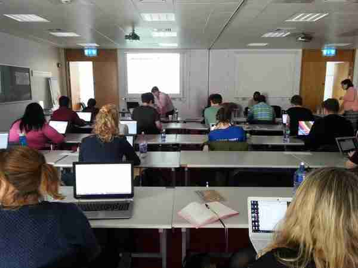

# R-Ladies

- 2 active groups
  - the original: R-Ladies San Fransisco
  - new for 2016:  
    R-ladies London

**Looking for new founders**

[figure not shown]

# On Ramps for Contributing

- Several R packages on GitHub have a CONTRIBUTING.md
  - often not designed for novices
- Target issues at novices
  - use tags
  - step-by-step instructions

[figure not shown]

# Supporting the Taskforce

- Follow us @RWomenTaskforce
- Complete our survey
- Further opportunities:
  - Organisers/mentors for training
  - Web developers
  - R-ladies founders
  - Sponsors
- Potential for co-ordinating funding applications
- Ideas/offers to rowforwards@gmail.com